# Lab01 - Parte 4

Caio Oliveira

May 25, 2017

# Laboratório 1, Parte 4: Relatório final

## Tema: Análise dos dados do IMDB

….

### Tratamento inicial dos dados

#### Aqui comecei o tratamento dos dados, primeiro uma variável que será usada na primeira pergunta, que é com todas as séries. A segunda variável vai ser usada na segunda pergunta.

```r
setwd("~/data-analysis-2/ad1/lab1")
data <- read.csv("series_from_imdb.csv")
series.selected.all.seasons <- data %>% filter(series_name %in% c("Arrow", "Sense8", "Daredevil", "Gotham", "Flash", "House of Cards"))

series.2.seasons <- series.selected.all.seasons %>%
  filter(season < 3)
```

….

### Quais são as top 10 melhores séries avaliadas? E quais são as piores?

#### Para responder essas perguntas fiz um estudo baseado na soma de votos total e na média do rating dado pelos usuários. Fiz tanto para o caso dos melhores como os piores, gerando assim 4 gráficos de barra que me surpreenderam bastante principalmente na relação de algumas séries tem quem poucos votos mas são muito bem avaliadas.

```r
a <- data.frame(data$series_name, data$UserVotes)
a <- na.omit(a)
colnames(a)[1] <- "name"
colnames(a)[2] <- "UserVotes"

series.per.vote <- a %>%
  group_by(name) %>%
  summarise(votos = sum(UserVotes))
series.per.vote <- na.omit(series.per.vote)

least.voted <- head(series.per.vote[order(series.per.vote$votos, decreasing = FALSE), ], n = 10)
most.voted <- head(series.per.vote[order(series.per.vote$votos, decreasing = TRUE), ], n = 10)


least.voted$name <- factor(least.voted$name, levels = least.voted$name[order(least.voted$votos)])
most.voted$name <- factor(most.voted$name, levels = most.voted$name[order(most.voted$votos)])
```

#### Já para as menos votadas vemos que Scandal aparece junto de 13 Reasons Why que é uma série recente da Netflix. E a melhor das piores é Vikins, o que me susrpreendeu muito pois é uma série extremamente popular e muito bem falada, revisada e avaliada.

```r
least.voted
```

```
## # A tibble: 10 × 2
##                           name  votos
##                         <fctr>  <dbl>
## 1                      Scandal  33412
## 2               13 Reasons Why  34228
## 3                       Sense8  35927
## 4                 Orphan Black  37760
## 5  How to Get Away with Murder  48429
## 6                       Narcos  50427
## 7              Stranger Things  61532
## 8                The Blacklist  88569
## 9                     Mr Robot  97947
## 10                     Vikings 111877
```

```r
most.voted
```

```
## # A tibble: 10 × 2
##                     name   votos
##                   <fctr>   <dbl>
## 1        Game of Thrones 1314771
## 2       The Walking Dead  816971
## 3           Breaking Bad  771233
## 4           The Simpsons  560091
## 5                Friends  454412
## 6  How I Met Your Mother  438492
## 7                  Arrow  344112
## 8                 Dexter  290806
## 9               Sherlock  289974
## 10                 Flash  238132
```

….

#### Como podemos observar nesses gráficos que seguem podemos ver as séries mais votadas e menos votadas, divididas por cores.

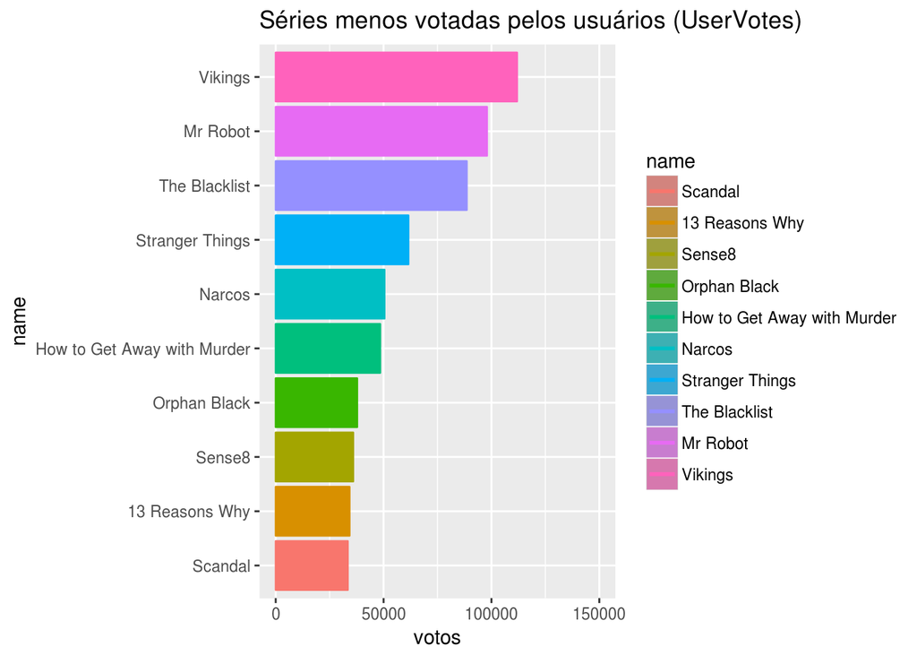

```r
lv.plot <- ggplot(arrange(least.voted, votos), aes(name, votos, colour = name)) + geom_col(aes(fill=name)) + ylim(0, 150000)  + geom_smooth(method="lm") + coord_flip() + ggtitle("Séries menos votadas pelos usuários (UserVotes)")

mv.plot <- ggplot(arrange(most.voted, votos), aes(name, votos, colour = name)) + geom_col(aes(fill=name)) + ylim(0, 1500000)  + geom_smooth(method="lm") + coord_flip() + ggtitle("Séries mais votadas pelos usuários (UserVotes)")


lv.plot
```

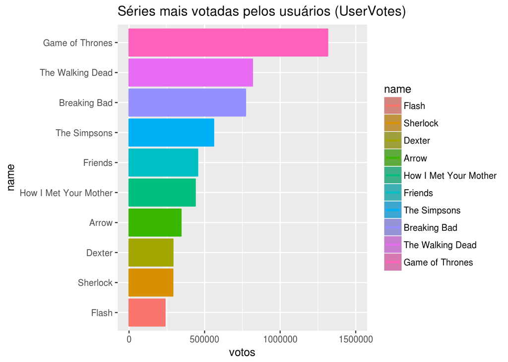

```r
mv.plot
```

#### Para a outra variável que é o UserRating fiz o mesmo estudo comparando as séries e podemos ver que para o caso de Narcos, que é muito bem avaliáda nesse caso, é uma das séries que aparece no outro gráfico como uma das menos votadas, junto com Mr. Robot, que é exatamente o mesmo caso.

```r
a <- data.frame(data$series_name, data$UserRating)
a <- na.omit(a)
colnames(a)[1] <- "name"
colnames(a)[2] <- "UserRating"

series.per.vote <- a %>%
  group_by(name) %>%
  summarise(votos = mean(UserRating))
series.per.vote <- na.omit(series.per.vote)

least.voted <- head(series.per.vote[order(series.per.vote$votos, decreasing = FALSE), ], n = 10)
most.voted <- head(series.per.vote[order(series.per.vote$votos, decreasing = TRUE), ], n = 10)


least.voted$name <- factor(least.voted$name, levels = least.voted$name[order(least.voted$votos)])
most.voted$name <- factor(most.voted$name, levels = most.voted$name[order(most.voted$votos)])
```

#### Aqui foi feito o mesmo estudo das top 10 e bottom 10 mais bem avaliadas segundo a média do UserRating. Dois casos chamaram muito atenção que foram os dois piores: Modern Family e The Simpsons; No caso dos Simpsons a quantidade de temporadas (28) tem uma variação muito grande de qualidade e principalmente de votos, isso explica a média mais baixa. Entretanto Modern Family foi um surpresa maior, já que até ganhou mais de uma vez o Golden Globe de melhor série de comédia.

#### Para o caso das melhores avaliadas podemos perceber predominância de séries da HBO e Netflix.

```r
least.voted
```

```
## # A tibble: 10 × 2
##                     name    votos
##                   <fctr>    <dbl>
## 1           The Simpsons 7.366721
## 2          Modern Family 7.989305
## 3                The 100 8.094643
## 4                Scandal 8.138462
## 5  How I Met Your Mother 8.229327
## 6         Grey’s Anatomy 8.287973
## 7           Black Mirror 8.307692
## 8       The Walking Dead 8.327273
## 9          The Blacklist 8.343678
## 10              Homeland 8.401389
```

```r
most.voted
```

```
## # A tibble: 10 × 2
##                           name    votos
##                         <fctr>    <dbl>
## 1              Game of Thrones 9.046667
## 2                    Daredevil 8.996154
## 3                 Breaking Bad 8.985484
## 4              Stranger Things 8.900000
## 5                       Sense8 8.891304
## 6                     Mr Robot 8.877273
## 7                     Sherlock 8.866667
## 8                       Narcos 8.800000
## 9  How to Get Away with Murder 8.751111
## 10                       Flash 8.717647
```

#### Como podemos ver nos gráficos a seguir.

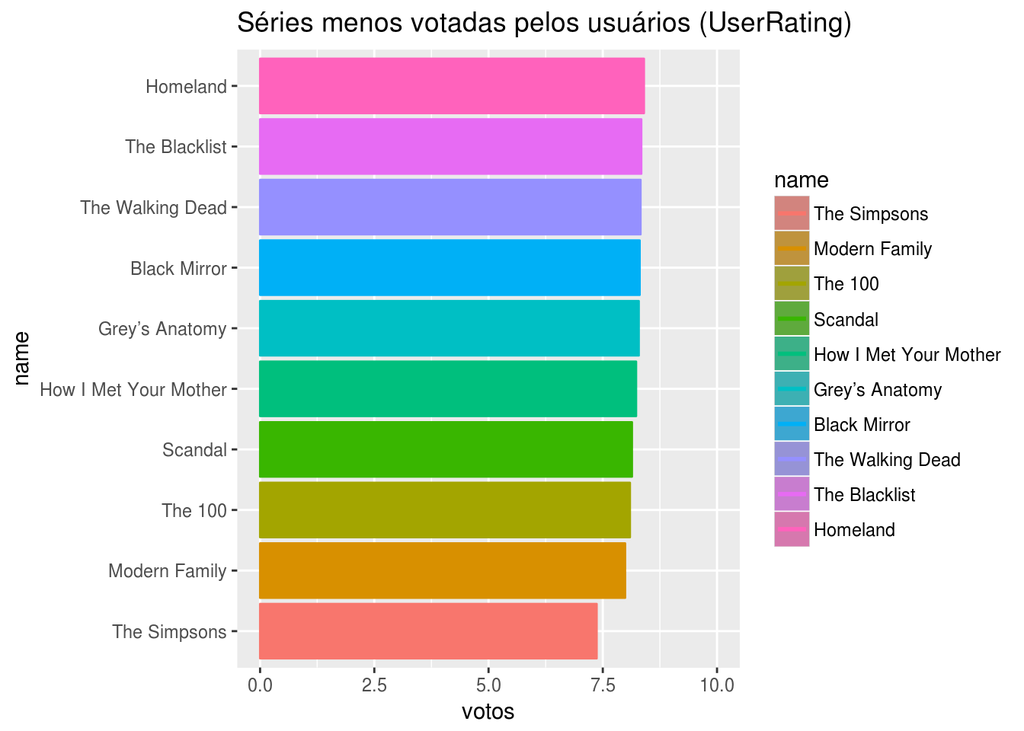

```r
lv.plot <- ggplot(arrange(least.voted, votos), aes(name, votos, colour = name)) + geom_col(aes(fill=name)) + ylim(0, 10)  + geom_smooth(method="lm") + coord_flip() + ggtitle("Séries menos votadas pelos usuários (UserRating)")

mv.plot <- ggplot(arrange(most.voted, votos), aes(name, votos, colour = name)) + geom_col(aes(fill=name)) + ylim(0, 10)  + geom_smooth(method="lm") + coord_flip() + ggtitle("Séries mais votadas pelos usuários (UserRating)")


lv.plot
```

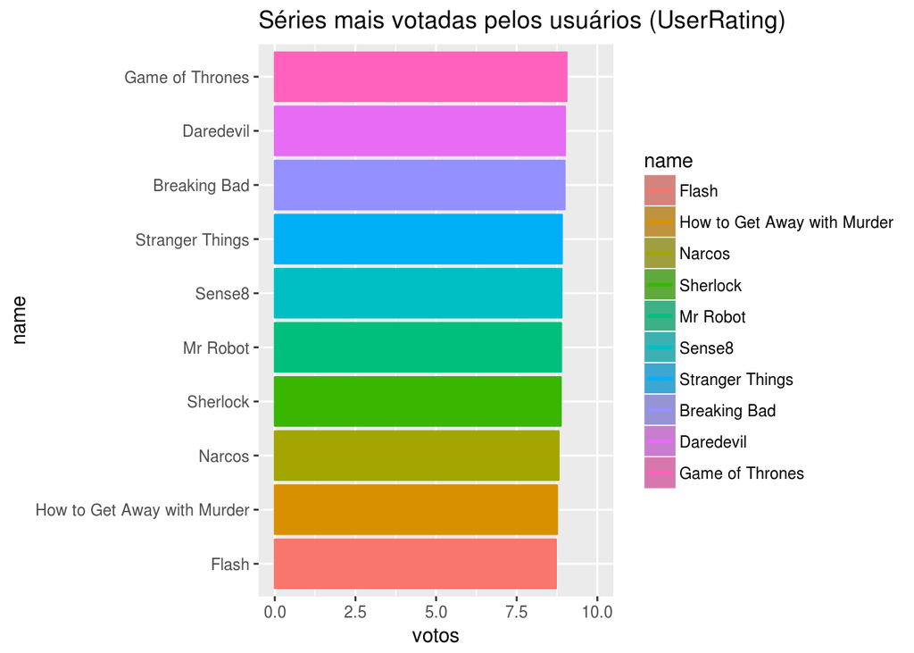

```r
mv.plot
```

### Dado um conjunto finito de séries com segunda temporada, geralmente qual temporada tem melhores notas? A primeira ou a segunda?

#### A principal motivação dessa pergunta foram os comentários em quase todas as séries que acompanho, as pessoas em geral preferem a primeira temporada, então decidi tirar a prova disso com os dados fornecidos pelo professor.

```r
series.2 <-  data.frame(series.2.seasons$series_name,series.2.seasons$season,series.2.seasons$UserRating, stringsAsFactors=FALSE)

series.2 <- na.omit(series.2)
colnames(series.2)[1] <- "name"
colnames(series.2)[2] <- "season"
colnames(series.2)[3] <- "UserRating"
series.2 <- series.2 %>% mutate(name = as.character(name))
series.2[] <- lapply(series.2, function(x) type.convert(as.character(x)))



series.season.1 <- series.2 %>%
  group_by(name,season) %>%
  filter(season == 1) %>%
  summarise(media = mean(UserRating))

series.season.2 <- series.2 %>%
  group_by(name,season) %>%
  filter(season == 2) %>%
  summarise(media = mean(UserRating))

series.formated <- rbind(series.season.1,series.season.2)
series.formated <- series.formated %>% mutate(name.def =
sprintf("%s.%d", name, season))
```

#### Nesse gráfico a primeira temporada sendo tanto indicada pelo número 1 como o azul marinho, e a segunda temporada sendo o azul claro, além do label 2.

#### Podemos comprovar que surpreendentemente para todas as séries (exceto The Flash) a segunda temporada é melhor avaliada que a primeira. Inclusive para séries que não existe uma demora tão grande para lançar outras temporadas, como é o caso de Arrow.

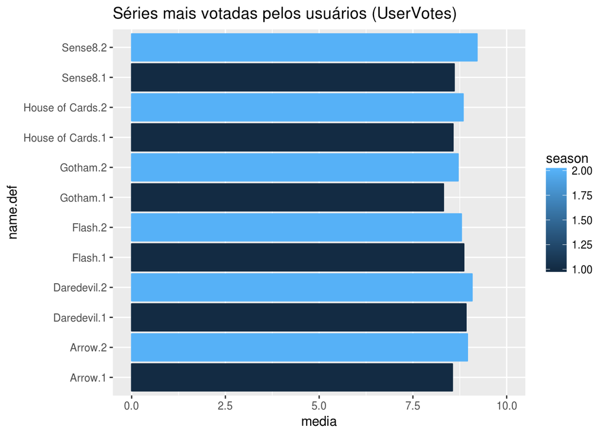

```r
plot.segundo.grupo <- ggplot(series.formated, aes(name.def, media, colour = season)) + geom_col(aes(fill=season)) + ylim(0, 10)  + geom_smooth(method="lm") + coord_flip() + ggtitle("Séries mais votadas pelos usuários (UserVotes)")
plot.segundo.grupo
```

```r
#ggplot(ddf, aes(x=GRP, y=NUMS)) + geom_boxplot(outlier.shape=NA) + geom_jitter(position=position_jitter(width=.1, height=0))
```